# index

DS Project 220 olympics games dataset analysis by Oghenemarho Ayanruoh and Vedh Thoutireddy

-We are going to analyze the the data set of the olympics in the last 16 years.-

ABOUT THE DATA We use the dataset on the Olympic games available at: https://www.kaggle.com/datasets/andreinovikov/olym IMPORTS: We import the required libraries. In this case, we need Pandas and Matplotlib, so you can see in the following code we imported these libraries

```python
import pandas as pd
import matplotlib.pyplot as plt
data = pd.read_csv("olympic_games.csv")
data.columns
```

```
Index(['year', 'games_type', 'host_country', 'host_city', 'athletes', 'teams',
       'competitions', 'country', 'gold', 'silver', 'bronze'],
      dtype='object')
```

We use the data.columns to get all columns from the Olympic_games data.

In the following coding snippet, we used data.head() to display the top five rows of the Olympic_games data:

```python
import pandas as pd
import matplotlib.pyplot as plt
data = pd.read_csv("olympic_games.csv")
data.head()
```

|  | year | games_type | host_country | host_city | athletes | teams | competitions | country | gold | silver | bronze |
| --- | --- | --- | --- | --- | --- | --- | --- | --- | --- | --- | --- |
| 0 | 2022 | Winter | China | Beijing | 2834 | 91 | 109 | Australia | 1 | 2 | 1 |
| 1 | 2022 | Winter | China | Beijing | 2834 | 91 | 109 | Austria | 7 | 7 | 4 |
| 2 | 2022 | Winter | China | Beijing | 2834 | 91 | 109 | Belarus | 0 | 2 | 0 |
| 3 | 2022 | Winter | China | Beijing | 2834 | 91 | 109 | Belgium | 1 | 0 | 1 |
| 4 | 2022 | Winter | China | Beijing | 2834 | 91 | 109 | Canada | 4 | 8 | 14 |

In the following coding snippet, we used data.tail() to display the bottom five rows of the Olympic_games data:

```python
import pandas as pd
import matplotlib.pyplot as plt
data = pd.read_csv("olympic_games.csv")
data.tail()
```

|  | year | games_type | host_country | host_city | athletes | teams | competitions | country | gold | silver | bronze |
| --- | --- | --- | --- | --- | --- | --- | --- | --- | --- | --- | --- |
| 1776 | 1896 | Summer | Greece | Athens | 241 | 14 | 43 | Hungary | 2 | 1 | 3 |
| 1777 | 1896 | Summer | Greece | Athens | 241 | 14 | 43 | Mixed team | 1 | 0 | 1 |
| 1778 | 1896 | Summer | Greece | Athens | 241 | 14 | 43 | Switzerland | 1 | 2 | 0 |
| 1779 | 1896 | Summer | Greece | Athens | 241 | 14 | 43 | United Kingdom | 3 | 3 | 3 |
| 1780 | 1896 | Summer | Greece | Athens | 241 | 14 | 43 | United States of America | 11 | 7 | 2 |

In the following coding snippet, we used data.shape() to display the shape of the Olympic_games data; it has 1781 rows and 11 columns.

```python
import pandas as pd
import matplotlib.pyplot as plt
data = pd.read_csv("olympic_games.csv")
data.shape
```

```
(1781, 11)
```

```python
data_16yr = data.iloc[0:489, [0,1,2,4,5,7,8,9,10] ]
data_16yr
```

|  | year | games_type | host_country | athletes | teams | country | gold | silver | bronze |
| --- | --- | --- | --- | --- | --- | --- | --- | --- | --- |
| 0 | 2022 | Winter | China | 2834 | 91 | Australia | 1 | 2 | 1 |
| 1 | 2022 | Winter | China | 2834 | 91 | Austria | 7 | 7 | 4 |
| 2 | 2022 | Winter | China | 2834 | 91 | Belarus | 0 | 2 | 0 |
| 3 | 2022 | Winter | China | 2834 | 91 | Belgium | 1 | 0 | 1 |
| 4 | 2022 | Winter | China | 2834 | 91 | Canada | 4 | 8 | 14 |
| ... | ... | ... | ... | ... | ... | ... | ... | ... | ... |
| 484 | 2006 | Winter | Italy | 2508 | 80 | Sweden | 7 | 2 | 5 |
| 485 | 2006 | Winter | Italy | 2508 | 80 | Switzerland | 5 | 4 | 5 |
| 486 | 2006 | Winter | Italy | 2508 | 80 | Ukraine | 0 | 0 | 2 |
| 487 | 2006 | Winter | Italy | 2508 | 80 | United Kingdom | 0 | 1 | 0 |
| 488 | 2006 | Winter | Italy | 2508 | 80 | United States of America | 9 | 9 | 7 |

489 rows × 9 columns

We can see the columns of the new DataFrame (data_16yr) by using data_16yr.columns.

```python
data_16yr.columns
```

```
Index(['year', 'games_type', 'host_country', 'athletes', 'teams', 'country',
       'gold', 'silver', 'bronze'],
      dtype='object')
```

```python
data_16yr.isnull().sum()
```

```
year            0
games_type      0
host_country    0
athletes        0
teams           0
country         0
gold            0
silver          0
bronze          0
dtype: int64
```

Null Values: We used the isnull() function to check the null values present in the data frame. As shown below, we see that no column has null values, hence we don't need to drop any rows.

```python
data_16yr.duplicated().sum()
```

```
0
```

In the above coding snippet, we have checked for duplicates and found that there is no duplicate data present:

```python
data_16yr.dtypes
```

```
year             int64
games_type      object
host_country    object
athletes         int64
teams            int64
country         object
gold             int64
silver           int64
bronze           int64
dtype: object
```

Checking the datatypes of the columns: In the following coding snippet, we printed the data types for all columns in the DataFrame:

Q.1) What is the total number of participants in each individual olympics from 2006 - 2022?

What is the total number of participants in each individual olympics from 2006 - 2022? In the following code snippet we attempted to find the total number of participants in each olympics game from 2006 - 2022. We first grouped the data by year and then added up the summation of participants in each year. Then we graphically plotted the reults using the matplotlib which is a python library which makes it very easy to graphically represent data by providing ready to use commands.

```
year
2006      65208
2008     951954
2010      66716
2012     908848
2014      72280
2016     966468
2018      84990
2020    1062060
2022      82186
Name: athletes, dtype: int64
```

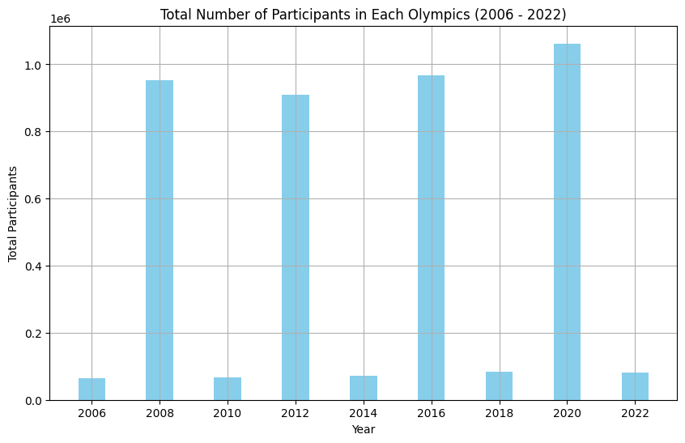

```python
total_participants_per_year = data_16yr.groupby('year')['athletes'].sum()
print (total_participants_per_year)
plt.figure(figsize=(10, 6))
plt.bar(total_participants_per_year.index, total_participants_per_year.values, color='skyblue')
plt.xlabel('Year')
plt.ylabel('Total Participants')
plt.title('Total Number of Participants in Each Olympics (2006 - 2022)')
plt.xticks(total_participants_per_year.index)
plt.grid(True)
plt.show()
```

Q.2) Top 10 countries that have won the most gold medals in the olympics from 2006 - 2022?

TOP 10 COUNTRIES THAT HAVE WON THE MOST GOLD MEDALS IN THE OLYMPICS FROM 2006 - 2022?

In the following coding snippet, we have tried to select the top 10 countries recorded with the most gold medals in the olmpics from 2006 - 2022. We group the data and sort it in a descending order. After that, we use the code snippet to create a plot of the top 10 countries that have won the most gold medals in the olympics from 2006 - 2022.

```
country
United States of America      213
People's Republic of China    171
Germany                       109
United Kingdom                101
Russian Federation             82
Japan                          64
Republic of Korea              63
Netherlands                    62
Canada                         62
Norway                         61
Name: gold, dtype: int64
```

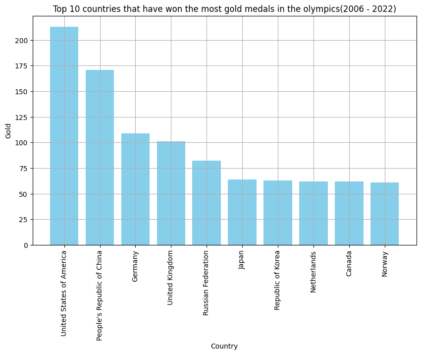

```python
top_10_most_gold = data_16yr.groupby('country')['gold'].sum()
top_10_most_goldd = top_10_most_gold.sort_values(ascending=False)[0:10]
print(top_10_most_goldd)

plt.figure(figsize=(10, 6))  # Adjust the size as needed
plt.bar(top_10_most_goldd.index, top_10_most_goldd.values, color='skyblue')
plt.xlabel('Country', fontsize = 10)
plt.ylabel('Gold')
plt.title('Top 10 countries that have won the most gold medals in the olympics(2006 - 2022)')
plt.xticks(rotation ='vertical' , fontsize = 10)
plt.xticks(top_10_most_goldd.index)  # Ensures all years are displayed on x-axis
plt.grid(True)
plt.show()
```

```python
least_gold = data_16yr.groupby('country')['gold'].sum()
least_goldd = least_gold.sort_values(ascending=True)[0:29]
print(least_goldd)
```

```
country
Afghanistan             0
Guatemala               0
Iceland                 0
Kuwait                  0
Kyrgyzstan              0
Liechtenstein           0
Malaysia                0
Mauritius               0
Cyprus                  0
Moldova                 0
Montenegro              0
Namibia                 0
Gabon                   0
Niger                   0
Nigeria                 0
Burundi                 0
Chile                   0
North Macedonia         0
United Arab Emirates    0
Turkmenistan            0
Togo                    0
Burkina Faso            0
Sudan                   0
Saudi Arabia            0
Syrian Arab Republic    0
Samoa                   0
Botswana                0
San Marino              0
Ghana                   0
Name: gold, dtype: int64
```

Q.4) Which olympic year had the most number of teams participating from 2006-2022?

WHICH OLYMPIC YEAR HAD THE MOST NUMBER OF TEAMS PARTICIPATING FROM 2006-2022?

We first grouped the data by year and added the summation of the participating teams in each year. We then used the idxmax() method, which return a Series with the index of the maximum value for each column. This made us find the year that had the most number of teams participating in the olympics from 2006-2022.

```python
totalteams_per_year = data_16yr.groupby('year')['teams'].sum()
year_with_most_teams = totalteams_per_year.idxmax()
print (f" The year with the most olympic teams participating was {year_with_most_teams}")
```

```
 The year with the most olympic teams participating was 2020
```

Q.5)Which olympic year had the least number of teams participating from 2006-2022?

WHICH OLYMPIC YEAR HAD THE LEAST NUMBER OF TEAMS PARTICPATING FROM 2006-2022?

We first grouped the data by year and added the summation of the participating teams in each year. We then used the idxmin() method, which return a Series with the index of the minimum value for each column. This made us find the year that had the least number of teams participating in the olympics from 2006-2022.

```python
totalteams_per_year = data_16yr.groupby('year')['teams'].sum()
year_with_least_teams = totalteams_per_year.idxmin()
print (f" The year with the least olympic teams participating was {year_with_least_teams}")
```

```
 The year with the least olympic teams participating was 2006
```

Q.6) Does game type affect total number of participants?

DOES THE GAME TYPE AFFECT TOTAL NUMBER OF PARTICIPANTS?

In the following code snippet we attempted to figure out if the game type affected the number of participating athletes in the olympics games from 2006 - 2022. We first grouped the data by games type and then added up the summation of the participating athletes in each year. Then we graphically plotted the results using the matplotlib which is a python library which makes it very easy to graphically represent data by providing ready to use commands.

```
games_type
Summer    3889330
Winter     371380
Name: athletes, dtype: int64
```

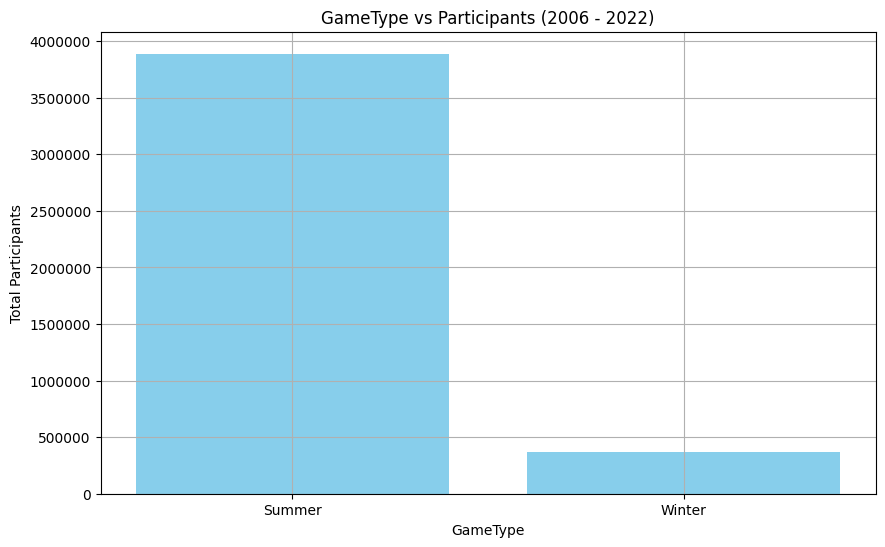

```python
participants_by_gametype = data_16yr.groupby('games_type')['athletes'].sum()
print (participants_by_gametype)
plt.figure(figsize=(10, 6))
plt.ticklabel_format(style='plain')
plt.bar(participants_by_gametype.index, participants_by_gametype.values, color='skyblue')
plt.xlabel('GameType')
plt.ylabel('Total Participants')
plt.title('GameType vs Participants (2006 - 2022)')
plt.xticks(participants_by_gametype.index)
plt.grid(True)
plt.show()
```

Q.7)Does hosting the olympics have a correlation to achieving either bronze,silver or gold from 2006-2022?

Does hosting the olympics have a correlation to achieving either bronze,silver or gold from 2006-2022?

In this Python code snippet, we begin by importing Pandas and Matplotlib libraries, which are essential for data manipulation and visualization, respectively. The data is then loaded from a CSV file named olympic_games.csv into a Pandas DataFrame for processing. The code specifically selects a subset of this data, focusing on rows 0 to 489 and a set of relevant columns, to analyze the medal counts from the Olympic Games.

To distinguish between host and non-host countries, a new column, 'IsHost', is created by comparing the 'Country' field to the 'HostCountry' field within the DataFrame. This boolean column is crucial for the subsequent grouping operation, where the DataFrame is grouped by the 'IsHost' status. For each group, the sum of 'Gold', 'Silver', and 'Bronze' medals is calculated to get the total medal counts for host and non-host countries.

To prepare the data for visualization, the aggregated medal counts DataFrame is transposed,so that each row represents a medal type and each column represents the host status: making it ready for plotting. The code then proceeds to plot a bar chart, with the x-axis representing the type of medal and the y-axis showing the total count of medals. The chart includes a title, axis labels, and a legend that distinguishes between host and non-host countries, providing a clear visual comparison of medal counts across the specified years from 2006 to 2022. The use of plt.show() at the end of the snippet ensures that the generated plot is displayed to the user.

```
        gold  silver  bronze
IsHost
False   1663    1686    1899
True      68      45      47
```

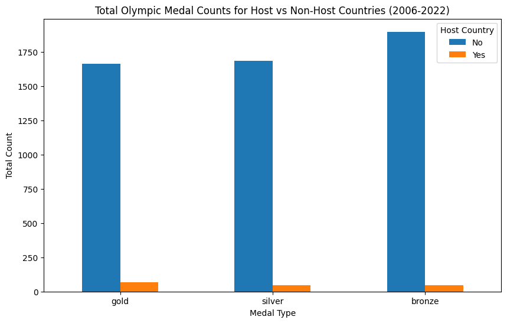

```python
import pandas as pd
import matplotlib.pyplot as plt
data = pd.read_csv("olympic_games.csv")
data_16yr = data.iloc[0:489, [0,1,2,4,5,7,8,9,10] ]
# Filter and determine host status
data_16yr['IsHost'] = data_16yr['country'] == data_16yr['host_country']
# Aggregate medal counts by host status
medal_counts = data_16yr.groupby('IsHost').agg({'gold': 'sum', 'silver': 'sum', 'bronze': 'sum'})
print(medal_counts)
# Transpose for easier plotting
medal_counts = medal_counts.T

# Plotting
medal_counts.plot(kind='bar', figsize=(10, 6))
plt.title('Total Olympic Medal Counts for Host vs Non-Host Countries (2006-2022)')
plt.xlabel('Medal Type')
plt.ylabel('Total Count')
plt.xticks(rotation=0)
plt.legend(title='Host Country', labels=['No', 'Yes'])
plt.show()
```